# LCL Fiber-seq: top 10 heterozygous AS-FIRE regions

### rank03_rs4061832_chr3_98334086_98334294

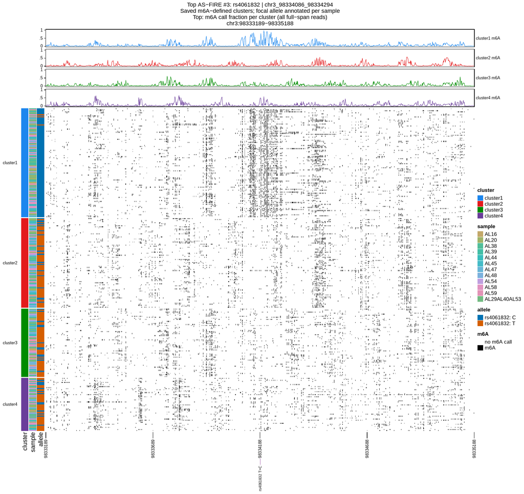

rank03_rs4061832_chr3_98334086_98334294 — m6A and footprint heatmaps

Download original PDF: heatmap_m6a_footprints

### rank04_rs170738_chr5_55421001_55421578

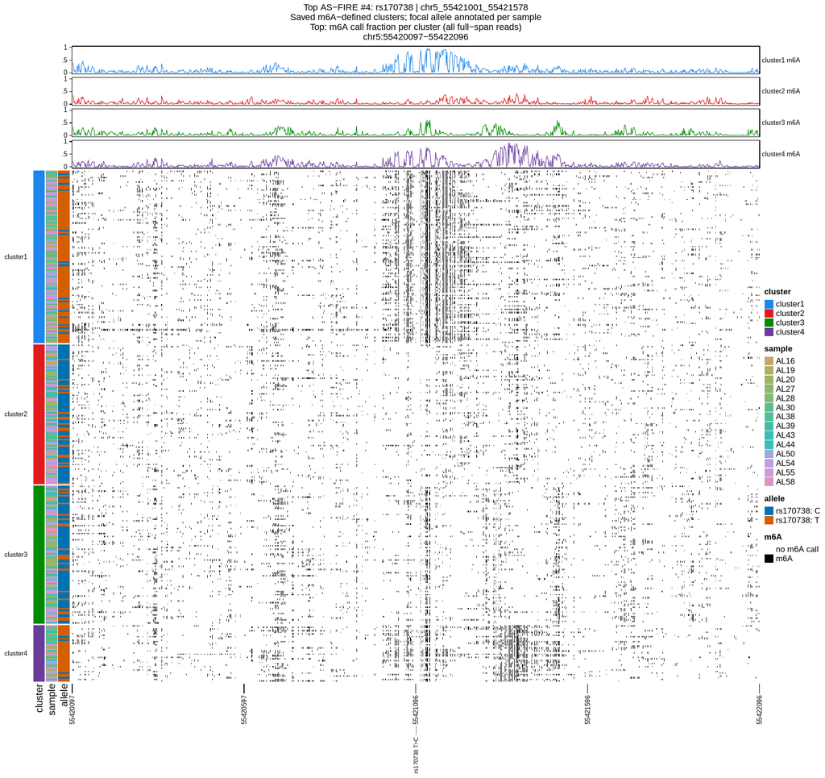

rank04_rs170738_chr5_55421001_55421578 — m6A and footprint heatmaps

Download original PDF: heatmap_m6a_footprints

### rank05_rs1457288_chr8_109521517_109521780

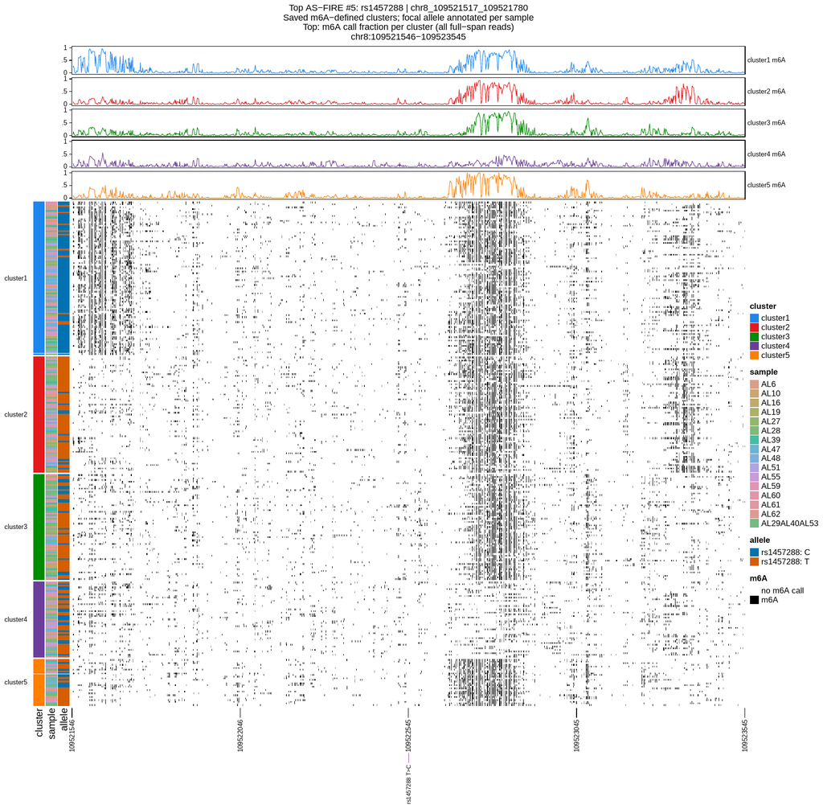

rank05_rs1457288_chr8_109521517_109521780 — m6A and footprint heatmaps

Download original PDF: heatmap_m6a_footprints

### rank06_rs10826861_chr10_30751957_30752154

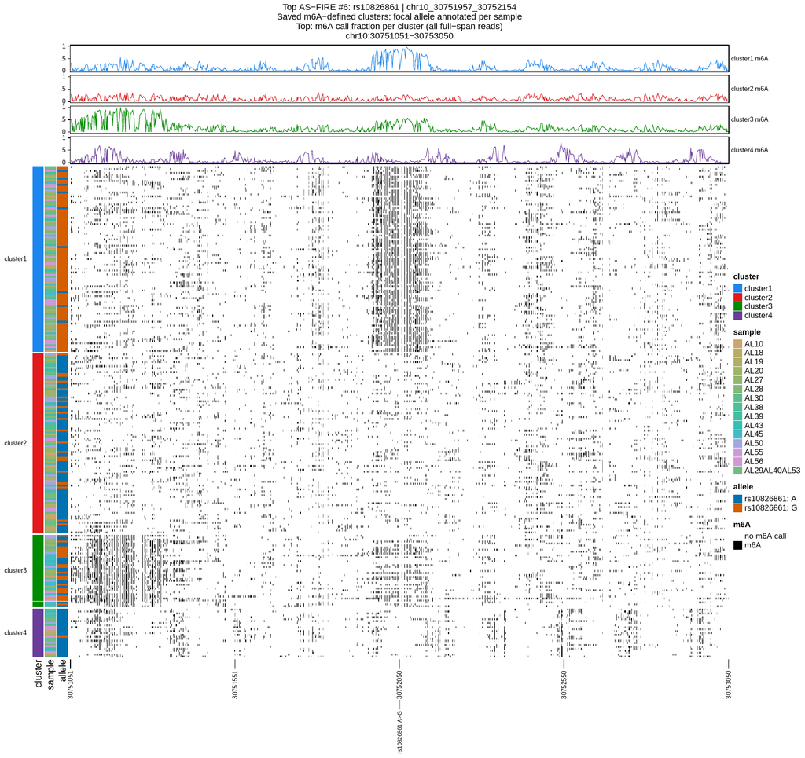

rank06_rs10826861_chr10_30751957_30752154 — m6A and footprint heatmaps

Download original PDF: heatmap_m6a_footprints

### rank07_rs1999686_chr9_31146879_31147088

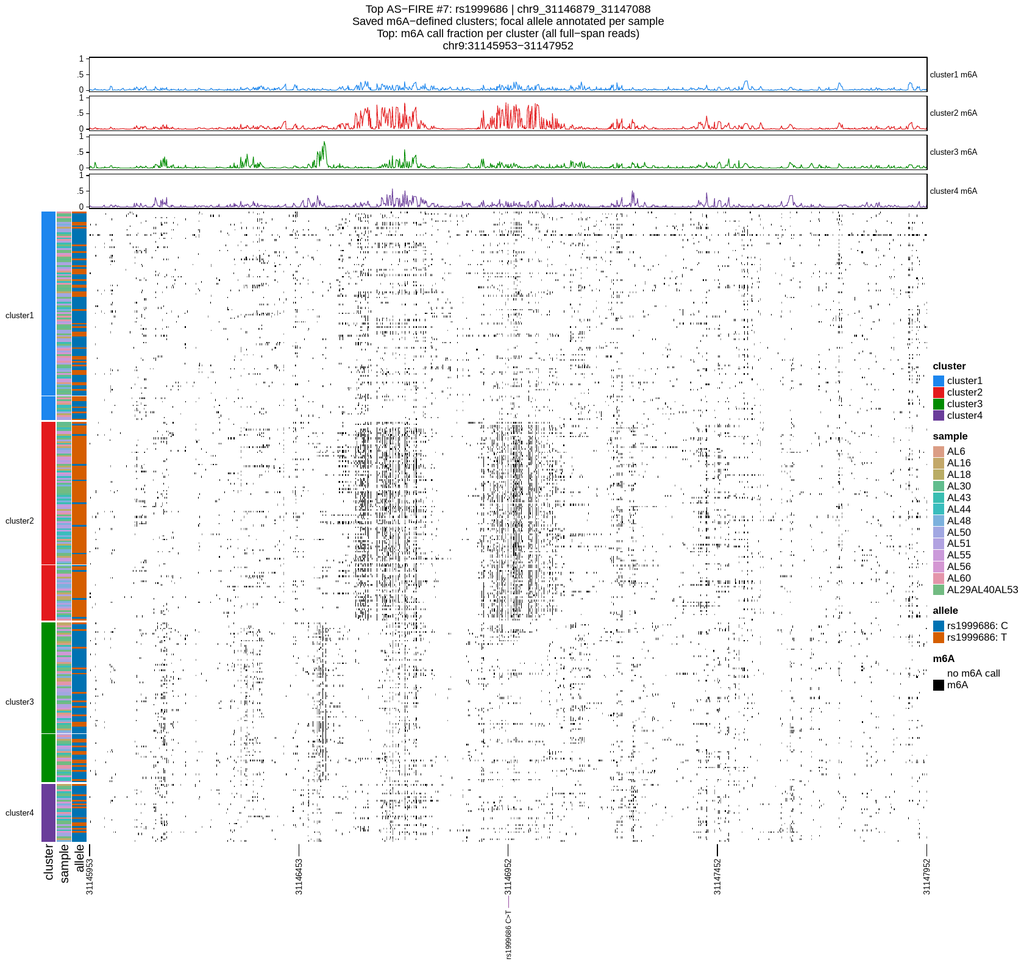

rank07_rs1999686_chr9_31146879_31147088 — m6A and footprint heatmaps

Download original PDF: heatmap_m6a_footprints

### rank08_rs12666349_chr7_31688407_31688773

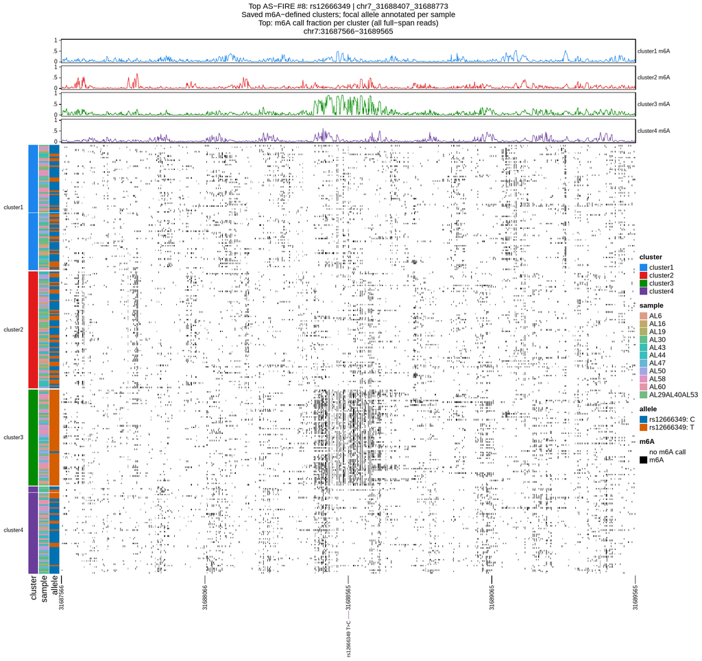

rank08_rs12666349_chr7_31688407_31688773 — m6A and footprint heatmaps

Download original PDF: heatmap_m6a_footprints

### rank09_rs17306827_chr2_173899075_173899320

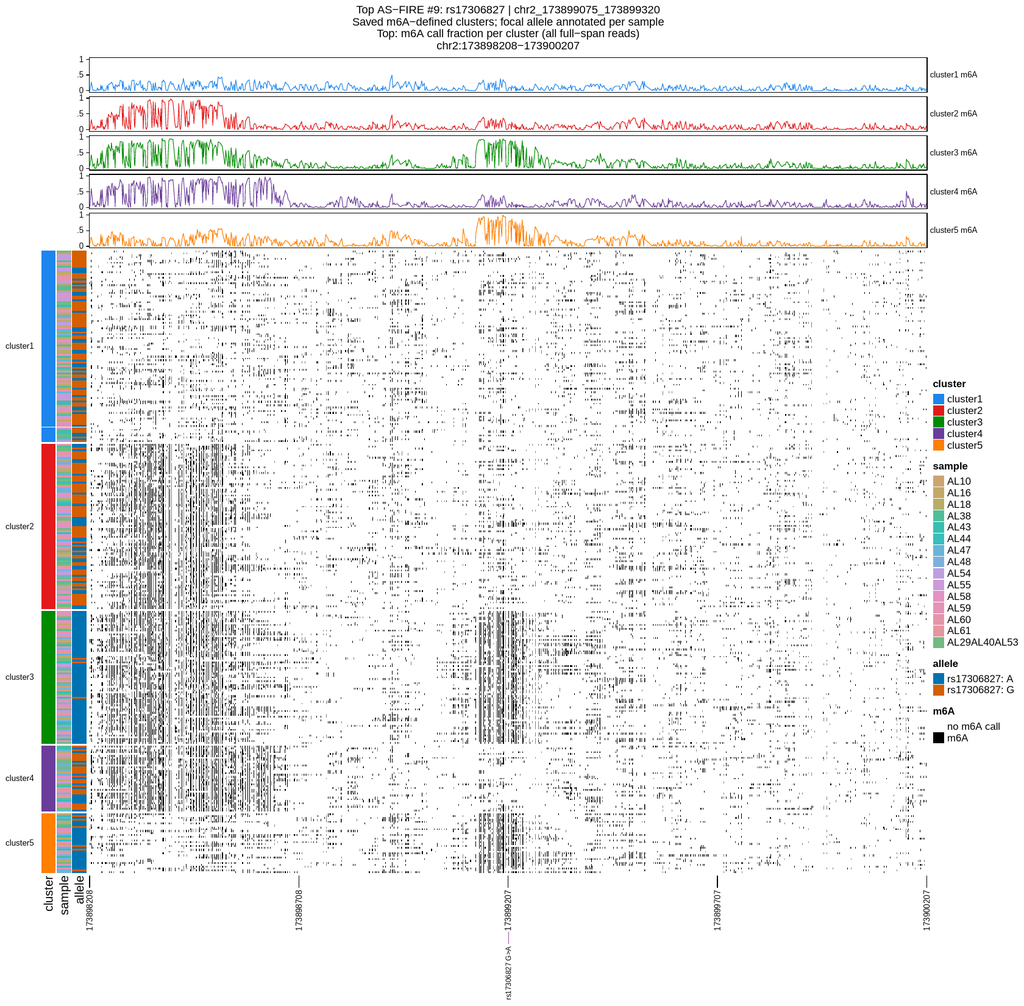

rank09_rs17306827_chr2_173899075_173899320 — m6A and footprint heatmaps

Download original PDF: heatmap_m6a_footprints

### rank10_rs2210798_chr6_8481830_8482016

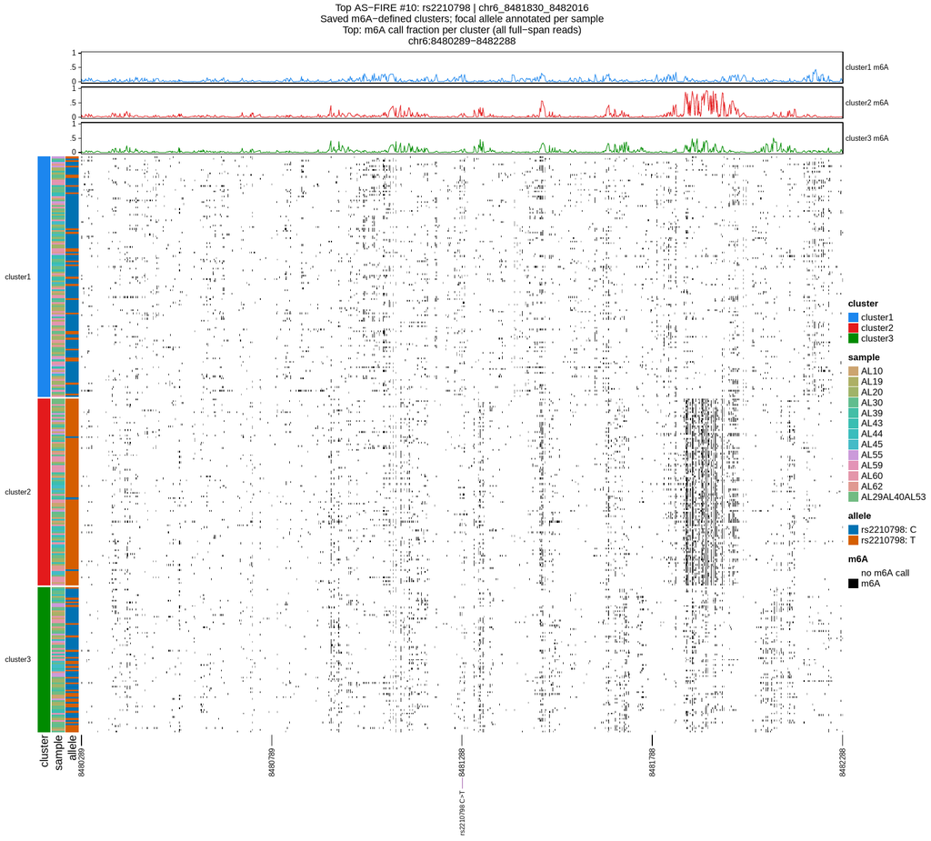

rank10_rs2210798_chr6_8481830_8482016 — m6A and footprint heatmaps

Download original PDF: heatmap_m6a_footprints

```r
for (rid in names(result_paths)) {
  plot_dir <- lcl_output_path(file.path(dirname(dirname(result_paths[[rid]])), "plots"))
  graph_pdf <- file.path(plot_dir, "knn_graph.pdf")
  if (!file.exists(graph_pdf)) {
    result <- readRDS(result_paths[[rid]])
    dir.create(plot_dir, recursive = TRUE, showWarnings = FALSE)
    ggplot2::ggsave(graph_pdf, plot_knn_graph(result), width = 12, height = 9, bg = "white")
  }
}
figure_gallery("knn_graph", "Manhattan KNN graphs colored by Leiden cluster")
```

## Manhattan KNN graphs colored by Leiden cluster

### rank01_rs12470189_chr2_119290945_119291178

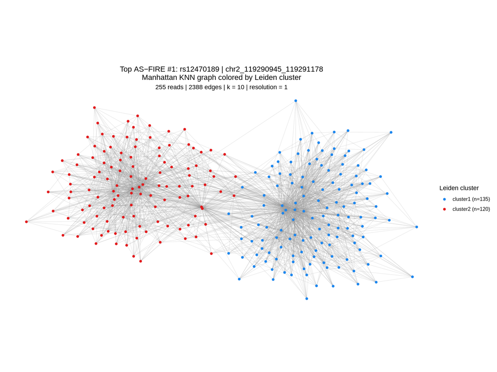

rank01_rs12470189_chr2_119290945_119291178 — Manhattan KNN graphs colored by Leiden cluster

Download original PDF: knn_graph

### rank02_rs2236610_chr21_34688259_34688428

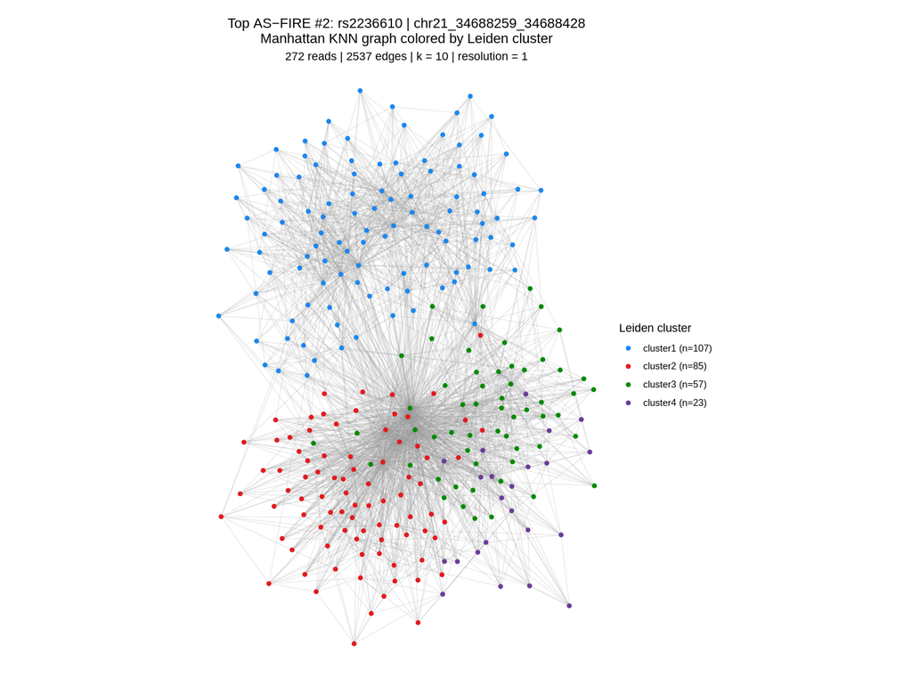

rank02_rs2236610_chr21_34688259_34688428 — Manhattan KNN graphs colored by Leiden cluster

Download original PDF: knn_graph

### rank03_rs4061832_chr3_98334086_98334294

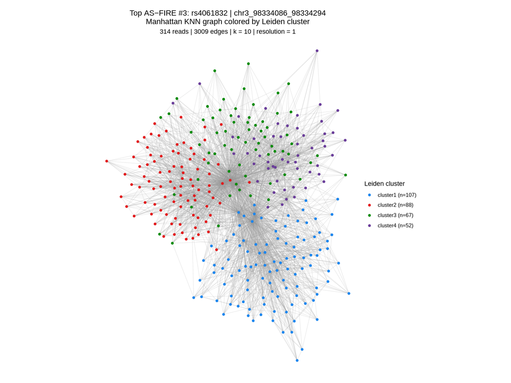

rank03_rs4061832_chr3_98334086_98334294 — Manhattan KNN graphs colored by Leiden cluster

Download original PDF: knn_graph

### rank04_rs170738_chr5_55421001_55421578

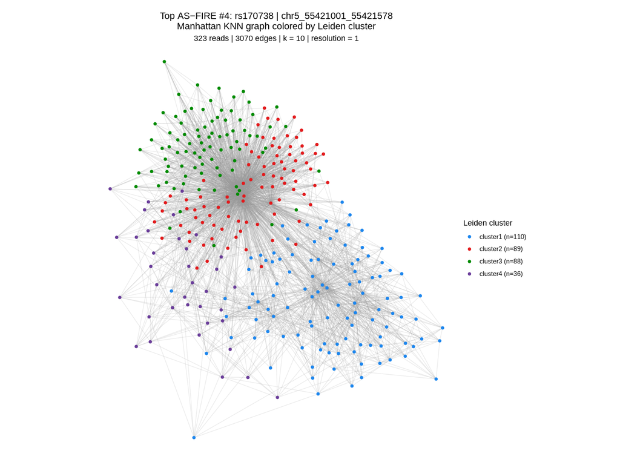

rank04_rs170738_chr5_55421001_55421578 — Manhattan KNN graphs colored by Leiden cluster

Download original PDF: knn_graph

### rank05_rs1457288_chr8_109521517_109521780

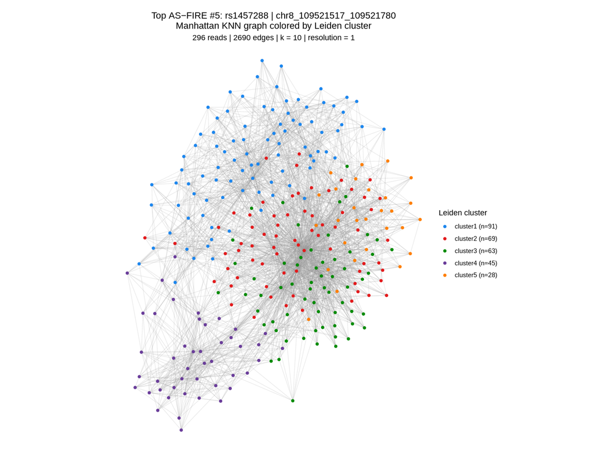

rank05_rs1457288_chr8_109521517_109521780 — Manhattan KNN graphs colored by Leiden cluster

Download original PDF: knn_graph

### rank06_rs10826861_chr10_30751957_30752154

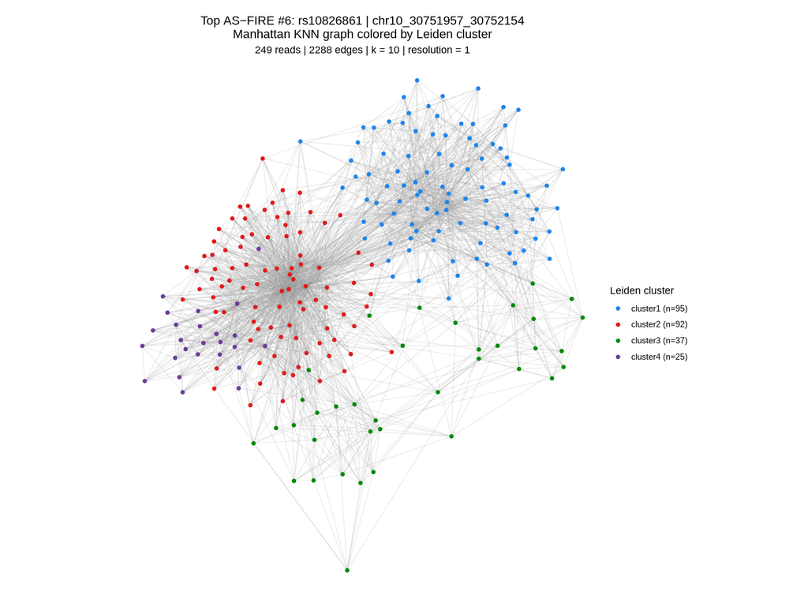

rank06_rs10826861_chr10_30751957_30752154 — Manhattan KNN graphs colored by Leiden cluster

Download original PDF: knn_graph

### rank07_rs1999686_chr9_31146879_31147088

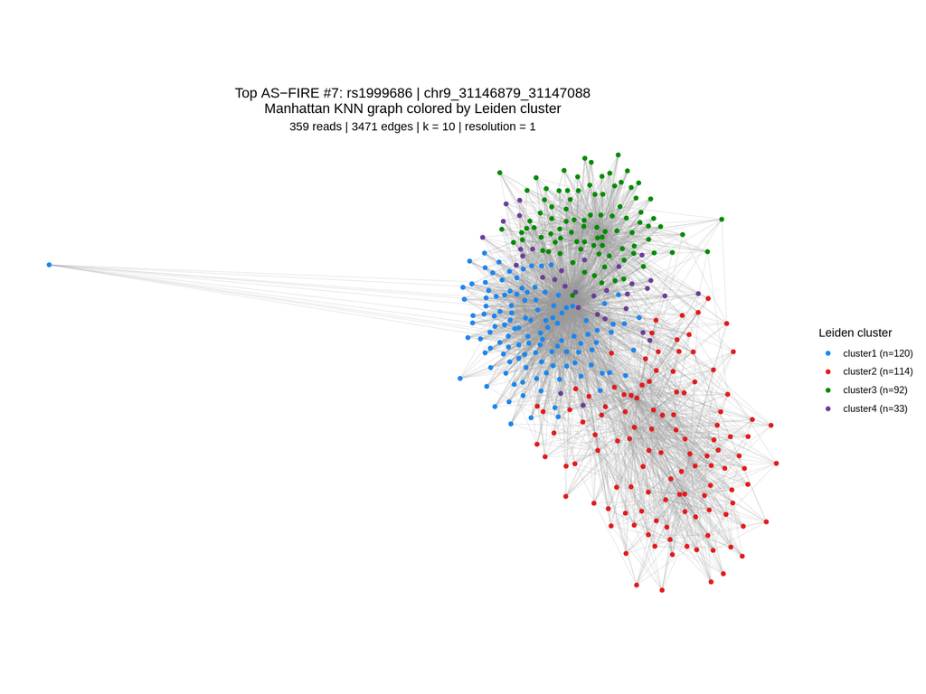

rank07_rs1999686_chr9_31146879_31147088 — Manhattan KNN graphs colored by Leiden cluster

Download original PDF: knn_graph

### rank08_rs12666349_chr7_31688407_31688773

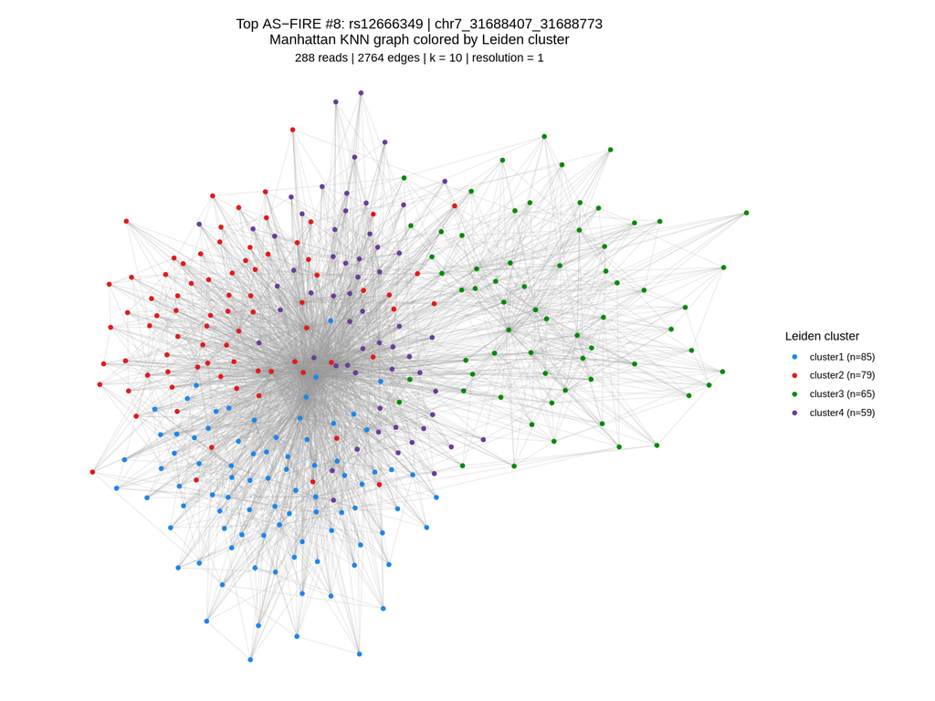

rank08_rs12666349_chr7_31688407_31688773 — Manhattan KNN graphs colored by Leiden cluster

Download original PDF: knn_graph

### rank09_rs17306827_chr2_173899075_173899320

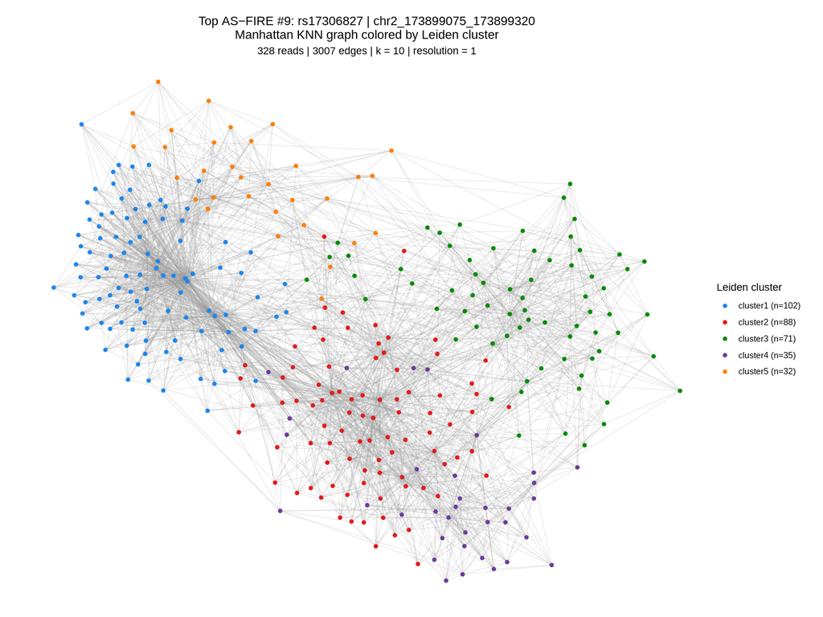

rank09_rs17306827_chr2_173899075_173899320 — Manhattan KNN graphs colored by Leiden cluster

Download original PDF: knn_graph

### rank10_rs2210798_chr6_8481830_8482016

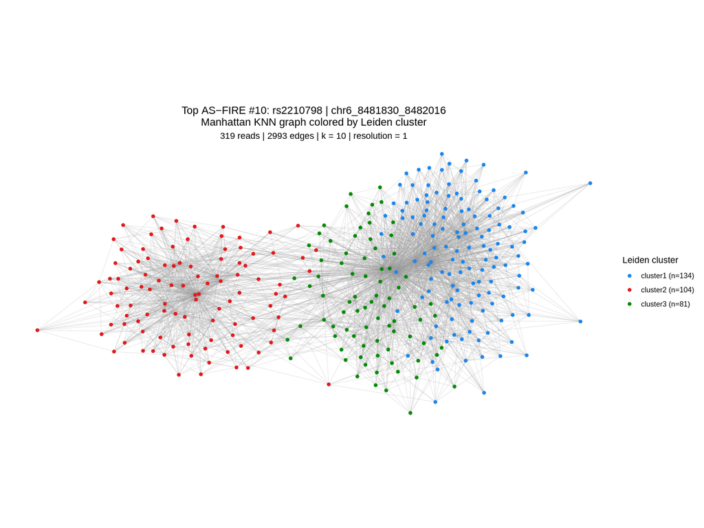

rank10_rs2210798_chr6_8481830_8482016 — Manhattan KNN graphs colored by Leiden cluster

Download original PDF: knn_graph

#### Outputs

The final output location is `/project/spott/cshan/fiber-seq/LCL_project/Leiden_manhattan`. Each of the ten region folders contains `bin0/k10/resolution1/plots` and `tables`

`tables` has saved clustering objects (`clustering.rds` and `fiberseq_annotated_clustering.rds`)

Selection follows [Kevin’s heterozygous AS-FIRE examples](https://kevinlkx.github.io/fiber-seq-analysis/example_figures_with_merged_samples.html#AS-fire_results).